# Inference For Linear Regression

To do inference, it is necessary to know the sampling distribution of the slope under the hypothesis that there is no relationship between the response and explanatory variables. In other words, you are taking the sample distribution under the conditions that the null hypothesis is TRUE. Permutation

Permuting is a way of sampling the data such that the response and explanatory values are not samples in the original pairs.

In the mid-20th century, a study was conducted that tracked down identical twins that were separated at birth: one child was raised in the home of their biological parents and the other in a foster home. In an attempt to answer the question of whether intelligence is the result of nature or nurture, both children were given IQ tests. The resulting data is given for the IQs of the foster twins (Foster is the response variable) and the IQs of the biological twins (Biological is the explanatory variable).

```r
library(infer)
library(tidyverse)
twins <- read.csv("data/twins.csv", header = T)

head(twins, 5)
```

```
##   Foster Biological Social
## 1     82         82   high
## 2     80         90   high
## 3     88         91   high
## 4    108        115   high
## 5    116        115   high
```

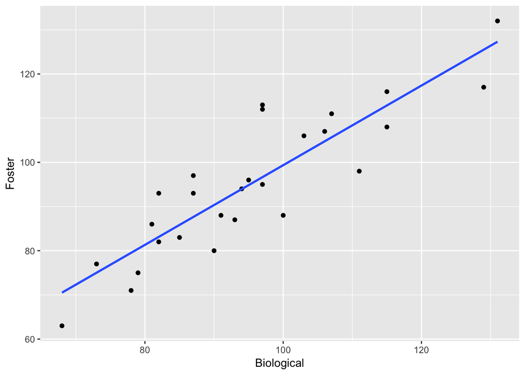

```r
ggplot(twins, aes(x = Biological, y = Foster)) +
  geom_point() +
  geom_smooth(method = "lm", se = F)
```

Calculate the observed slope of the dataset

```r
#load broom package for tidying models
library(broom)

#obtain the slope value as a vector (pull function returns selected column as a vector)
obs_slope <- lm(Foster ~ Biological, data = twins) %>%
  tidy() %>%
  filter(term == "Biological") %>%
  pull(estimate)

obs_slope
```

```
## [1] 0.901436
```

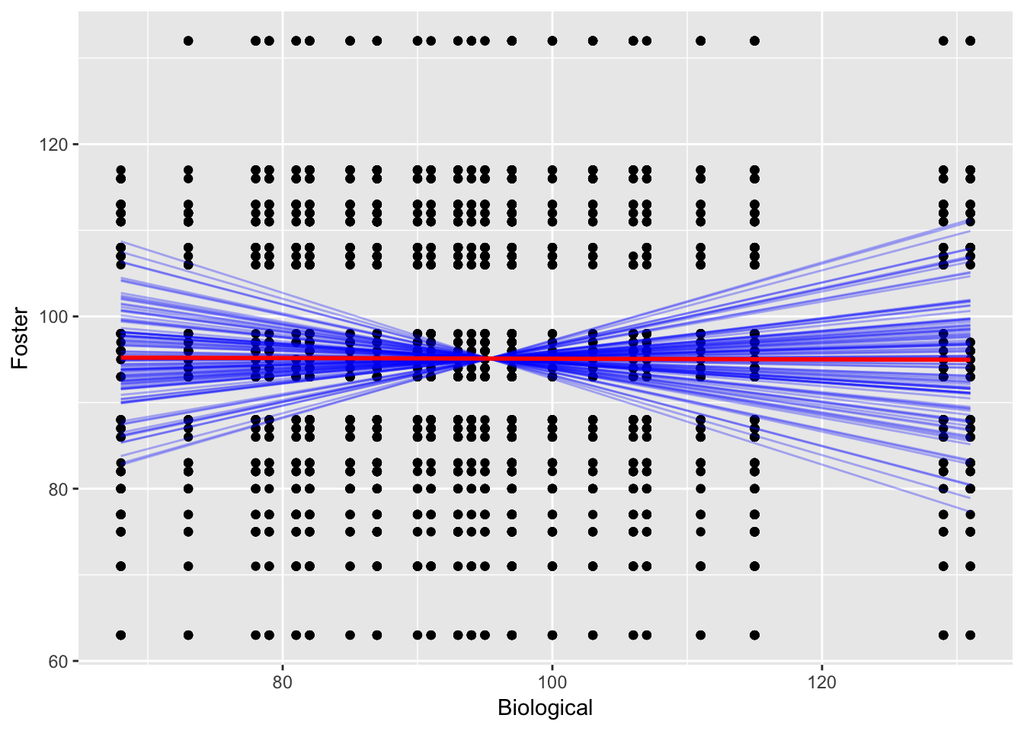

```r
#set seed for reproducibility
set.seed(1234)

perm_data <- twins %>%
  specify(Foster ~ Biological) %>%
  hypothesize(null = "independence") %>%
  generate(reps = 100, type = "permute")

ggplot(perm_data, aes(x = Biological, y = Foster)) +
  geom_point() +
  geom_line(stat = "smooth", method = "lm", se = F, aes(group = replicate), color = "blue", alpha = 0.3) +
  geom_smooth(method = 'lm', se = F, color = "red")
```

As you see above, we have created a permuted dataset where the slopes are now centered around 0. Below we willcalculate the values of the slopes and plot them on a histogram against the observed slope.

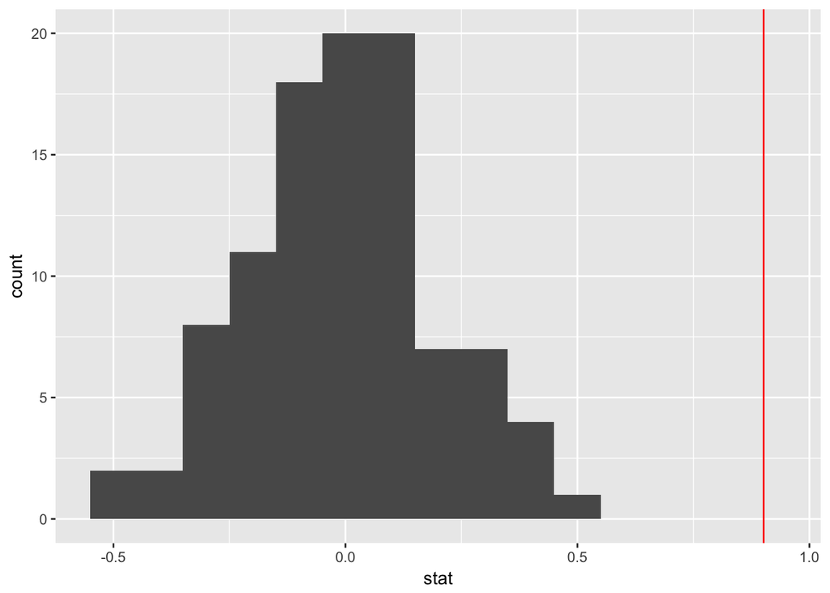

```r
#calculate the slope values of the perm_slopes
perm_slopes <- perm_data %>%
  calculate(stat = "slope")

#view distirbution of the permuted slopes vs. the observed_slope
ggplot(perm_slopes, aes(x = stat)) +
  geom_histogram(bins = 15) +
  geom_vline(xintercept = obs_slope, color = "red")
```

Now that we have created the null sampling distribution, we can use it to find the p-value associated with the original slope statistic from the twins data. We will calculate the absolute value to make it a two-sided test.

```r
# Calculate the absolute value of the slope
abs_obs_slope <- lm(Foster ~ Biological, data = twins) %>%
  tidy() %>%
  filter(term == "Biological") %>%
  pull(estimate) %>%
  abs()

# Compute the p-value
perm_slopes %>%
  mutate(abs_perm_slope = abs(stat)) %>%
  summarize(p_value = mean(abs_perm_slope > abs_obs_slope))
```

```
## # A tibble: 1 x 1
##   p_value
##     <dbl>
## 1       0
```

We get a value of 0. This makes sense! What this tells us is that the probability of getting a value as or more extreme than what we observe in the original dataset (0.9) is 0 if the null hypothesis were true.

In other words, we would not expect to see a positive slope value of 0.9 if we sampled the distribution over and over and over again given that there is no relationship between the variables. Since this is not the case, we must reject the null hypothesis.

# Bootstrapping

Where as permuting the data is used for hypothesis testing, bootstrapping is another sampling method which can be used to determine the variation in your data.

Bootstrapping is a sampling method which consists of repeatedly sampling the data with replacement. This allows us to estimate the sampling distribution and standard error of the slope coefficient. Using the sampling distribution will allow you to directly find a confidence interval for the underlying population slope.

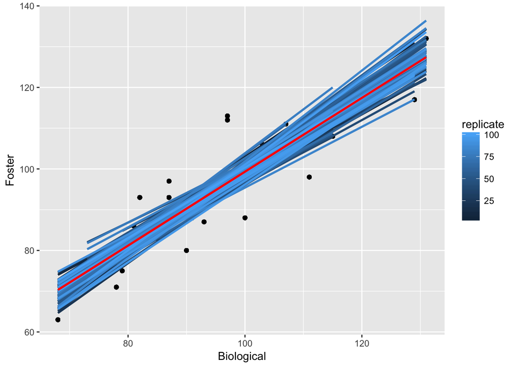

```r
# Bootstrap the slopes
set.seed(4747)
BS_data <- twins %>%
  specify(Foster ~ Biological) %>%
  generate(reps = 100, type = "bootstrap")

ggplot(BS_data, aes(x = Biological, y = Foster)) +
  geom_point() +
  geom_smooth(method = "lm", se = F, aes(group = replicate, color = replicate)) +
  geom_smooth(method = "lm", se = F, color = "red")
```

Now let’s calculate the slopes of the bootstrapped samples and use these to generate confidence intervals.

```r
#calculate slopes
BS_slopes <- BS_data %>%
  calculate(stat = "slope")

# Create a confidence interval
BS_slopes %>%
summarize(lower = mean(stat) -  2*sd(stat),
          upper = mean(stat) + 2*sd(stat))
```

```
## # A tibble: 1 x 2
##       lower    upper
##       <dbl>    <dbl>
## 1 0.7204311 1.090937
```

Alternatively, a CI for the slope can be created using the percentiles of the distribution of the bootstrapped slope statistics. We can calculate the percentiles using the `quantile` function.

```r
# Set alpha
alpha <- .05

quantile(BS_slopes$stat)
```

```
##        0%       25%       50%       75%      100%
## 0.6909442 0.8565140 0.9004897 0.9570960 1.1150348
```

```r
# Create a confidence interval
BS_slopes %>%
summarize(low = quantile(stat, alpha / 2),
          high = quantile(stat, 1 - alpha / 2))
```

```
## # A tibble: 1 x 2
##         low     high
##       <dbl>    <dbl>
## 1 0.7350211 1.085062
```